# Module 12 Lecture - Correlation and Linear Regression

Introduction to Statistical Methods

Quinton Quagliano, M.S., C.S.P

Department of Educational Psychology

# 1 Overview and Introduction

Agenda

1 Overview and Introduction

2 Basic Review of Linear Equations

3 Scatterplots & Graphical Methods

4 Correlation Coefficient r

5 Regression Equation

6 Conclusion

## 1.1 Textbook Learning Objectives

- Discuss basic ideas of linear regression and correlation.
- Create and interpret a line of best fit.
- Calculate and interpret the correlation coefficient.

## 1.2 Instructor Learning Objectives

- Understand the concept of prediction and how it ties into linear regression
- Begin to see the broader applications of regression outside the simple applications

## 1.3 Introduction

- In this unit, we will be describing both correlation and simple linear regression
  - At a basic level, these statistics are appropriate to continuous numeric variables with a ratio or interval scale of measurement
  - There are more advanced methods that can work with ordinal and categorical data, but they are out of scope for this class
- **Discuss: As review, describe what it means for a variable to be continuous and what the different between ratio and interval scale data are?**
- Furthermore, we’ll be primarily focusing on the **bivariate** scenario, where there are two variables we are comparing
  - This is usually set up as one **predictor** variable and one **criterion** variable
  - There are important (and commonly) used extensions for **multivariate** scenarios, but they involve more complex interpretation and assumptions
- Your book uses the terms “independent” and “dependent” to describe predictor and criterion variables, but I stay away from those terms unless the design of the study was experimental in nature
- **Important: Linear regression often shows up in cross-sectional or longitudinal research where it is difficult to say it can fully support a causal claim. Be careful in describing what exactly a regression model shows about the relationship between two or more variables**

# 2 Basic Review of Linear Equations

Agenda

1 Overview and Introduction

2 Basic Review of Linear Equations

3 Scatterplots & Graphical Methods

4 Correlation Coefficient r

5 Regression Equation

6 Conclusion

## 2.1 Introduction

- Many folks are introduced to the basic linear equation in algebra and/or geometry: $y = a + bx$
  - Where:
    - $y$ = criterion variable
    - $a$ = y-intercept or the value of $y$ when $x = 0$
    - $b$ = slope
    - $x$ = predictor variable
  - Alternative forms include: $y = b + mx$ or $y = mx + b$
    - All of these formulas mean the same thing
  - Signs of the slope and y-intercept can be negative
- Examples:
  - $y = 8 + 4x$
  - $y = 12x - 3$
  - $y = -10x + 9$ - shown in the graph below

Listing 1: Line Plot of y = -10x + 9

**R Code**

```r
x_vals <- seq(-2, 2, by = 0.1)
y_vals <- -10 * x_vals + 9 # NOTE: See equation here!
data <- data.frame(x = x_vals, y = y_vals)

ggplot(data, aes(x = x, y = y)) +
  geom_line(color = "red", size = 1.2) +
  labs(
    title = "",
    x = "x",
    y = "y"
  ) +
  theme_minimal()
```

[figure not shown]

- **Important: Pay attention to where the 0 on the x-axis is! It may not always be on the far left**
- If put on a graphical plot, this equation result in a straight line
  - If $b > 0 \rightarrow$ upward to right
  - If $b < 0 \rightarrow$ downward to right
  - If $b = 0 \rightarrow$ straight horizontal across
  - A higher $a$ / y-intercept will result in the line crossing the y-axis ($x=0$) at a higher point

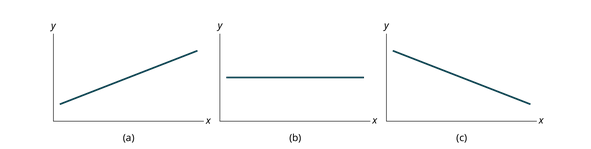

- **Question: Looking at the 3 graphs above, which one has the lowest y-intercept**
- A) Left
- B) Center
- C) Right
- D) All have the same y-intercept

# 3 Scatterplots & Graphical Methods

Agenda

1 Overview and Introduction

2 Basic Review of Linear Equations

3 Scatterplots & Graphical Methods

4 Correlation Coefficient r

5 Regression Equation

6 Conclusion

## 3.1 Introduction

- Early in the semester, we learned about graphical methods for showing descriptive information about individual, continuous variables, i.e., boxplots, histograms, stem-and-leaf plots
- **Discuss: Review: Take a look at the histogram and boxplot below, what can you say to describe this variable based on what they plots tell you?**

Listing 2: Histogram and boxplot of a hypothetical continuous variable

**R Code**

```r
histbox(normal_data, value, "Continuous Variable")
```

[figure not shown]

- In addition to ways we can graphically represent a single variable, we can also represent the bivariate scenario with a **scatterplot**
  - A scatterplot will be set up so that one of our variables is on the x-axis, and one of our variables is on the y-axis
  - It’s convention to put the predictor variable on the x-axis, and the criterion variable on the y-axis, but it’s not necessarily “wrong” to do the other way

Listing 3: Scatterplot Example

**R Code**

```r
# Create sample data
df <- data.frame(x = rnorm(50), y = rnorm(50))

# Create scatterplot with red points
ggplot(df, aes(x = x, y = y)) +
  geom_point(color = "red") +
  labs(title = "", x = "X", y = "Y") +
  theme_minimal()
```

[figure not shown]

- **Important: Remember, various graphs and plots are a great way for us to best understand our variables and relationships - we can and should use them often alongside our numeric results.**

## 3.2 Strength and Direction

- In a scatterplot, we can visually inspect the **strength** of the correlation, as well as the **direction** of the relationship
- The strength of a relationship indicates how closely related two variables are to one another
  - A higher strength indicates close/strong relationship, and is visually shown by points on a scatterplot sitting along a clear linear trend
  - Conversely, a lower strength would represent two variables not very related to one another, and be shown by a scatterplot where points do not seem to follow a line
- The direction of a relationship indicates how one variable reacts to change in the other
  - A **negative relationship** indicates that as one variable increases, the other decreases
  - A **positive relationship** indicated that as one variable increases, so does the other

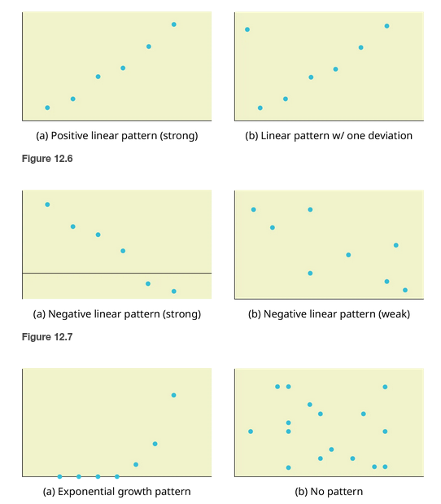

- **Discuss: Using the scatterplot below, describe the direction and strength of the relationship between the two variables x and y. Think about how an imaginary line between these points would look**

Listing 4: Hypothetical Scatterplot

**R Code**

```r
set.seed(42)
x <- seq(0, 10, length.out = 50)
y <- 2 * x + rnorm(50, mean = 0, sd = 1)
df <- data.frame(x = x, y = y)

# Create scatterplot
ggplot(df, aes(x = x, y = y)) +
  geom_point(color = "red", size = 3) +
  labs(title = "", x = "X", y = "Y") +
  theme_minimal()
```

[figure not shown]

# 4 Correlation Coefficient r

Agenda

1 Overview and Introduction

2 Basic Review of Linear Equations

3 Scatterplots & Graphical Methods

4 Correlation Coefficient r

5 Regression Equation

6 Conclusion

## 4.1 Introduction

- Pearson’s Product-moment Correlation Coefficient or $r$ for short, is the most commonly used statistic to numerically describe a non-directional, linear relationship between two variables
  - In this case, saying “non-directional” just means that it doesn’t necessarily tell us about one predicting or causing another
- **Important: It is incredibly important to remember that r can only be applied when we think there is a *linear* relationship between two variables. A scatterplot can help identify if this does appear to be a linear relationship**

## 4.2 Calculation

$$r = \frac{n\sum{(xy)} - (\sum{x})(\sum{y})}{\sqrt{[n\sum{x^2} -
(\sum{x})^2][n\sum{y^2} - (\sum{y})^2]}}$$

- Where:
  - $n$: the number of paired data points
  - $x$: individual data points in variable $X$
  - $y$: individual data points in variable $Y$
- **Important: Like with everything in statistics, there are several ways to write this same formula - but this is the most simplified version.**
- We’ll come back to work though this equation in the Full Worked Example

## 4.3 Interpretation

- Value:
  - Always true: $-1 \leq r \leq 1$
  - $r = 0$ suggests no relationship
  - $r = 1$ or $r = -1$ suggest a perfect relationship, i.e., a straight line on a scatterplot
  - $r$ closer to -1 or 1 (away from 0) suggests a stronger linear relationship
- Sign:
  - A negative sign for $r$ suggests a negative relationship
  - A positive sign for $r$ suggests a positive relationship
  - In relation to regression (which we’ll discuss in a moment), $r$ will have the same sign a $b$, or the slope of our line-of-best-fit
- Example:
  - I find that there is a strong positive correlation of GPA and SAT Score of $r = 0.76$
  - I find that there is weak negative correlation between salary and happiness (assume continuous) of $r = -0.21$
  - I find no relationship between mileage on cars and cost of cars of $r = 0.02$
- **Discuss: Describe the relationship between two variables with r = -0.80**

## 4.4 Significance

- $r$ is a sample statistic, and it’s corresponding parameter in the population is represented as $\rho$ (greek letter “rho”)
  - We can hypothesis test to see if $\rho$ is significantly different than 0
- **Important: Confusingly, there is a similar correlation coefficient for ordinal data called Spearman's rho, but that is not the same as what we are talking about here.**
- **Question: If we are testing our continuous, numeric coefficient against the arbitrary standard of 0, what test does that sound most similar to, of the ones we have covered so far?**
- A) Welch's t-test
- B) One-sample t-test
- C) Chi-square goodness-of-fit
- D) Chi-square test-of-independence
- Our hypothesis pair:
  - $H_0: \rho = 0$
  - $H_A: \rho \neq 0$
  - We decided whether we can reject the null hypothesis that $\rho = 0$
- There are several ways to calculate the p-value (which we won’t do by hand), but one of the common ways is via the t-statistic!

## 4.5 Coefficient of Determination (r-squared)

- We can also get $r^2$, called r-squared or the **coefficient of determination**
  - This is a way of representing how much variance in one variable is explained or accounted for by change in the other
- Example:
  - GRE scores correlate with later happiness, $r = 0.50 \rightarrow r^2 = 0.25$, thus 25% of the variance in happiness is explained by GRE score
- **Discuss: If I say that annual household spending and child GPA are correlated r = 0.12, write out how much variance is explained in the same manner as the above example.**

## 4.6 Full Worked Example

- Consider the following small sets of data:
  - $X: {1, 2, 3, 4} \rightarrow \bar{x} = 2.5, s_x = 1.29$
  - $Y: {2, 3, 6, 3} \rightarrow \bar{y} = 3.5, s_y = 1.73$
  - $n = 4$ sets of data points

$$r = \frac{n\sum{(xy)} - (\sum{x})(\sum{y})}{\sqrt{[n\sum{x^2} -
(\sum{x})^2][n\sum{y^2} - (\sum{y})^2]}}$$

| i | X | Y | X·Y | X² | Y² |
| --- | --- | --- | --- | --- | --- |
| 1 | 1 | 2 | 2 | 1 | 4 |
| 2 | 2 | 3 | 6 | 4 | 9 |
| 3 | 3 | 6 | 18 | 9 | 36 |
| 4 | 4 | 3 | 12 | 16 | 9 |
| **Σ** | **10** | **14** | **38** | **30** | **58** |

$$r = \frac{4(38) - (10)(14)}{\sqrt{[4(30) - 10^2]*[4(58) - 14^2]}} = 0.4472$$

- $r = 0.4472$ is
  - A moderately strong, positive correlation coefficient
  - $r = 0.4472 \rightarrow r^2 = 0.20 \rightarrow$ 20% of variance in Y is accounted for by X

# 5 Regression Equation

Agenda

1 Overview and Introduction

2 Basic Review of Linear Equations

3 Scatterplots & Graphical Methods

4 Correlation Coefficient r

5 Regression Equation

6 Conclusion

## 5.1 Introduction

- While graphical methods are useful, we often want numbers to back up our conclusions
- The purpose of simple linear regression analysis is to “fit” or “draw” a linear, straight line that goes through the center of all of our points, sometimes called the **line-of-best-fit**
  - There are many methods for the exact equation is used to minimize the distance to each point from our line-of-best-fit or **error**
  - For our simple use, the most common method is the **ordinary least-squares**

## 5.2 Minimizing Error

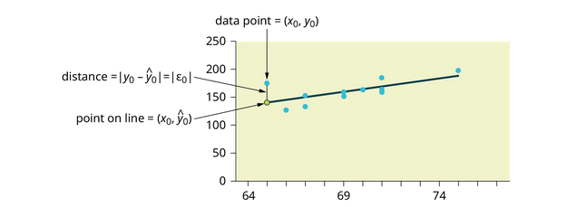

- Our line-of-best-fit is made up of infinitely many predicted or expected points with coordinates: $(\hat{x}, \hat{y})$ and passes through our observed data with coordinates: $(x, y)$
  - Thus, our error is the distance between the observed and the predicted points: $|y - \hat{y}| = \epsilon$, put another way, the distance on the y-axis that the predicted line is away from the observed point
  - We get an $\epsilon$ or error for each observed point:

$$(\epsilon_1)^2 + (\epsilon_2)^2 + ... + (\epsilon_n)^2 =
\sum_{i=1}\epsilon^2 = SSE$$

- The above equation gives us the **sum of squared errors (SSE)**
  - In least-squares regression, our goal is to fit a line that minimizes the SSE

## 5.3 The Regression Equation Calculation

- The line-of-best-fit that is fit to minimize SSE can be found in the sample, using this formula:

$$\hat{y} = a + bx$$

- Where:
  - $\hat{y}$: our predicted y-value at any given point
  - $a = \bar{y} - b\bar{x}$: y-intercept
  - $b = \frac{\sum{(x - \bar{x})(y - \bar{y})}}{\sum{x - \bar{x}^2}}$ or $b = r(\frac{s_y}{s_x})$: line slope
  - $\bar{x}$: Sample mean of variable $X$
  - $\bar{y}$: Sample mean of variable $Y$
  - $s_x$: Sample standard deviation of variable $X$
  - $s_y$: Sample standard deviation of variable $Y$
  - $r$: Pearson’s correlation coefficient
- As you can see, there are multiple steps and substitutions, but our hope is to get to a point in which we have values for both $a$ and $b$

## 5.4 Worked Example

- Consider the following small sets of data:
  - $X: {1, 2, 3, 4} \rightarrow \bar{x} = 2.5, s_x = 1.29$
  - $Y: {2, 3, 6, 3} \rightarrow \bar{y} = 3.5, s_y = 1.73$
  - $n = 4$ sets of data points
  - $r = 0.4472$
- Regression math
  - $a = 3.5 - 0.60(2.5) = 2$
  - $b = 0.4472(\frac{1.73}{1.29}) = 0.60$-ish
  - Final line equation: $\hat{Y} = 2.0 + 0.60x$
  - Practical reading: For every one unit increase in X, there is a 0.60 unit increase in Y; at x = 0, y = 2.0
- Predicting Y off specific value of X
  - If $x = 2$ then…
  - $\hat{Y} = 2.0 + 0.60(2) = 3.2$

# 6 Conclusion

Agenda

1 Overview and Introduction

2 Basic Review of Linear Equations

3 Scatterplots & Graphical Methods

4 Correlation Coefficient r

5 Regression Equation

6 Conclusion

## 6.1 Recap

- Correlation and regression both give us some helpful ways of calculating information about the relationships between two continuous variables (bivariate)
- One can determine both the direction and relative strength of the relationships between the variables
- One can also make a determination on predicting on variable based upon another, with the caveat that there can always be the chance of error in that prediction

## 6.2 Lecture Check-in

- Make sure to complete any lecture check-in tasks associated with this lecture!

[figure not shown]

Module 12 Lecture - Correlation and Linear Regression || Introduction to Statistical Methods